# Project 2 - MLR

Group 7

2022-08-10

```r
library(leaps)
library(MASS)
library(tidyverse)
library(faraway)
library(lawstat)
```

```r
kc <- read.csv('kc_house_data.csv', header = TRUE)
```

```r
# zipcodes with overall grades of atleast an A on https://www.niche.com/places-to-live/search/best-zip-codes-to-live/c/king-county-wa/?publicSchoolsGrade=a

zipcodes <- data.frame(zipcode = c(98004, 98005, 98052, 98121, 98007, 98109, 98033, 98122,
                         98029, 98006, 98103, 98102, 98074, 98101, 98040, 98115,
                         98112, 98107, 98119, 98105, 98075, 98008, 98116, 98053,
                         98034, 98039, 98144, 98199, 98117, 98104, 98028, 98027,
                         98011, 98177, 98125, 98065, 98072, 98077, 98126, 98155,
                         98136, 98059, 98133, 98118, 98106),
                       area_bin = c(1, 1, 1, 1, 1, 1, 1, 1, 1, 1, 1, 1, 1, 1, 1, 1, 1, 1, 1,
                         1, 1, 1, 1, 1, 1, 1, 1, 1, 1, 1, 1, 1, 1, 1, 1, 1, 1, 1,
                         1, 1, 1, 1, 1, 1, 1))
expanded_kc <- merge(x = kc, y = zipcodes, by = 'zipcode', all.x = T)
```

```r
filtered_kc <- expanded_kc %>%
  mutate(
    good_area = factor(ifelse(!is.na(area_bin), 1, 0)), ## using the grades from Niche
    renovated = factor(ifelse(yr_renovated > 0, 1, 0)),
    waterfront = factor(waterfront),
  ) %>%
  filter(bedrooms < 33) ## outlier likely entered incorrectly

set.seed(1) ## for reproducibility to get the same split
sample<-sample.int(nrow(filtered_kc), floor(.50*nrow(filtered_kc)), replace = F)
train<-filtered_kc[sample, ] ## training data frame
test<-filtered_kc[-sample, ] # #test data frame
```

```r
sqft_cols <- c('sqft_living', 'sqft_lot', 'sqft_above', 'sqft_basement', 'sqft_living15', 'sqft_lot15')
count_cols <- c('bedrooms', 'bathrooms', 'floors')
index_cols <- c('view', 'condition', 'grade')
```

```r
train[, c('price', sqft_cols)] %>%
  cor
```

```
##                    price sqft_living   sqft_lot  sqft_above sqft_basement
## price         1.00000000   0.7040940 0.08097223  0.60574004    0.33710168
## sqft_living   0.70409403   1.0000000 0.17300443  0.87620306    0.44931516
## sqft_lot      0.08097223   0.1730044 1.00000000  0.18165011    0.02200572
## sqft_above    0.60574004   0.8762031 0.18165011  1.00000000   -0.03686289
## sqft_basement 0.33710168   0.4493152 0.02200572 -0.03686289    1.00000000
## sqft_living15 0.58767353   0.7576633 0.14638411  0.73587734    0.20694426
## sqft_lot15    0.07623299   0.1906448 0.71925514  0.19941919    0.02564505
##               sqft_living15 sqft_lot15
## price             0.5876735 0.07623299
## sqft_living       0.7576633 0.19064478
## sqft_lot          0.1463841 0.71925514
## sqft_above        0.7358773 0.19941919
## sqft_basement     0.2069443 0.02564505
## sqft_living15     1.0000000 0.18091979
## sqft_lot15        0.1809198 1.00000000
```

```r
train[, c('price', count_cols)] %>%
  cor
```

```
##               price  bedrooms bathrooms    floors
## price     1.0000000 0.3268809 0.5317009 0.2560644
## bedrooms  0.3268809 1.0000000 0.5414737 0.1780887
## bathrooms 0.5317009 0.5414737 1.0000000 0.4885730
## floors    0.2560644 0.1780887 0.4885730 1.0000000
```

- Since the number of bathrooms and bedrooms are usually used for housing sales, we will use those two factors as predictors.

```r
train[, c('price', index_cols)] %>%
  cor
```

```
##                price       view   condition      grade
## price     1.00000000 0.41061323  0.03630437  0.6615186
## view      0.41061323 1.00000000  0.05130924  0.2657233
## condition 0.03630437 0.05130924  1.00000000 -0.1411458
## grade     0.66151864 0.26572333 -0.14114580  1.0000000
```

In addition to these, we will use location features as predictors: - good_area - waterfront

We will also be using the age of the house and if it has been renovated or not: - yr_built - renovated

```r
train <- train %>%
  subset(select = c(price, sqft_living, bedrooms, bathrooms, grade, good_area, waterfront, view, yr_built, renovated)) ##training data frame

test <- test %>%
  subset(select = c(price, sqft_living, bedrooms, bathrooms, grade, good_area, waterfront, view, yr_built, renovated)) ##test data frame
```

```r
regnull <- lm(price ~ 1, data = train) ##intercept-only model
regfull <- lm(price ~ ., data = train) ##model with all the predictors
```

### Stepwise

```r
step(regnull, scope=list(lower = regnull, upper = regfull), direction = 'both')
```

```
## Start:  AIC=277077.7
## price ~ 1
##
##               Df  Sum of Sq        RSS    AIC
## + sqft_living  1 7.3221e+14 7.4476e+14 269681
## + grade        1 6.4633e+14 8.3064e+14 270860
## + bathrooms    1 4.1755e+14 1.0594e+15 273489
## + view         1 2.4902e+14 1.2279e+15 275084
## + good_area    1 2.2644e+14 1.2505e+15 275281
## + bedrooms     1 1.5782e+14 1.3192e+15 275859
## + waterfront   1 9.7501e+13 1.3795e+15 276342
## + renovated    1 3.0715e+13 1.4463e+15 276853
## + yr_built     1 2.8006e+12 1.4742e+15 277059
## <none>                      1.4770e+15 277078
##
## Step:  AIC=269681
## price ~ sqft_living
##
##               Df  Sum of Sq        RSS    AIC
## + good_area    1 1.4741e+14 5.9736e+14 267300
## + view         1 6.2733e+13 6.8203e+14 268732
## + grade        1 5.6397e+13 6.8837e+14 268832
## + waterfront   1 5.4342e+13 6.9042e+14 268864
## + yr_built     1 4.6939e+13 6.9783e+14 268980
## + bedrooms     1 1.8881e+13 7.2588e+14 269406
## + renovated    1 1.4687e+13 7.3008e+14 269468
## <none>                      7.4476e+14 269681
## + bathrooms    1 1.6885e+09 7.4476e+14 269683
## - sqft_living  1 7.3221e+14 1.4770e+15 277078
##
## Step:  AIC=267299.8
## price ~ sqft_living + good_area
##
##               Df  Sum of Sq        RSS    AIC
## + view         1 6.1449e+13 5.3591e+14 266129
## + waterfront   1 5.9428e+13 5.3793e+14 266169
## + grade        1 2.8975e+13 5.6838e+14 266764
## + yr_built     1 2.4288e+13 5.7307e+14 266853
## + bedrooms     1 1.4129e+13 5.8323e+14 267043
## + renovated    1 1.1825e+13 5.8553e+14 267086
```

[output cut: 98 more lines]

```
## Step:  AIC=264002.4
## price ~ sqft_living + good_area + view + waterfront + grade +
##     yr_built + bedrooms + bathrooms + renovated
##
##               Df  Sum of Sq        RSS    AIC
## <none>                      4.3970e+14 264002
## - renovated    1 3.4558e+11 4.4004e+14 264009
## - bathrooms    1 3.8858e+12 4.4358e+14 264096
## - bedrooms     1 6.4187e+12 4.4611e+14 264157
## - view         1 1.2209e+13 4.5190e+14 264296
## - waterfront   1 2.3437e+13 4.6313e+14 264562
## - yr_built     1 3.5668e+13 4.7536e+14 264843
## - grade        1 4.1145e+13 4.8084e+14 264967
## - sqft_living  1 7.7167e+13 5.1686e+14 265748
## - good_area    1 8.1420e+13 5.2112e+14 265836
```

```
##
## Call:
## lm(formula = price ~ sqft_living + good_area + view + waterfront +
##     grade + yr_built + bedrooms + bathrooms + renovated, data = train)
##
## Coefficients:
## (Intercept)  sqft_living   good_area1         view  waterfront1        grade
##   4483418.4        183.1     193577.8      50839.5     572435.4      90497.5
##    yr_built     bedrooms    bathrooms   renovated1
##     -2604.8     -34972.2      42976.4      29268.8
```

### Regression Equation after Stepwise Regression:

(Starting with the intercept-only model)

Predictors selected: All the initial predictors were selected.

```r
step(regfull, scope=list(lower = regnull, upper = regfull), direction = 'both')
```

```
## Start:  AIC=264002.4
## price ~ sqft_living + bedrooms + bathrooms + grade + good_area +
##     waterfront + view + yr_built + renovated
##
##               Df  Sum of Sq        RSS    AIC
## <none>                      4.3970e+14 264002
## - renovated    1 3.4558e+11 4.4004e+14 264009
## - bathrooms    1 3.8858e+12 4.4358e+14 264096
## - bedrooms     1 6.4187e+12 4.4611e+14 264157
## - view         1 1.2209e+13 4.5190e+14 264296
## - waterfront   1 2.3437e+13 4.6313e+14 264562
## - yr_built     1 3.5668e+13 4.7536e+14 264843
## - grade        1 4.1145e+13 4.8084e+14 264967
## - sqft_living  1 7.7167e+13 5.1686e+14 265748
## - good_area    1 8.1420e+13 5.2112e+14 265836
```

```
##
## Call:
## lm(formula = price ~ sqft_living + bedrooms + bathrooms + grade +
##     good_area + waterfront + view + yr_built + renovated, data = train)
##
## Coefficients:
## (Intercept)  sqft_living     bedrooms    bathrooms        grade   good_area1
##   4483418.4        183.1     -34972.2      42976.4      90497.5     193577.8
## waterfront1         view     yr_built   renovated1
##    572435.4      50839.5      -2604.8      29268.8
```

### Regression Equation after Stepwise Regression:

(Starting with the model with all predictors)

Predictors selected: No predictors were dropped. Similar with the previous stepwise regression, all predictors were selected.

```r
step(regnull, scope=list(lower = regnull, upper = regfull), direction = 'forward')
```

```
## Start:  AIC=277077.7
## price ~ 1
##
##               Df  Sum of Sq        RSS    AIC
## + sqft_living  1 7.3221e+14 7.4476e+14 269681
## + grade        1 6.4633e+14 8.3064e+14 270860
## + bathrooms    1 4.1755e+14 1.0594e+15 273489
## + view         1 2.4902e+14 1.2279e+15 275084
## + good_area    1 2.2644e+14 1.2505e+15 275281
## + bedrooms     1 1.5782e+14 1.3192e+15 275859
## + waterfront   1 9.7501e+13 1.3795e+15 276342
## + renovated    1 3.0715e+13 1.4463e+15 276853
## + yr_built     1 2.8006e+12 1.4742e+15 277059
## <none>                      1.4770e+15 277078
##
## Step:  AIC=269681
## price ~ sqft_living
##
##              Df  Sum of Sq        RSS    AIC
## + good_area   1 1.4741e+14 5.9736e+14 267300
## + view        1 6.2733e+13 6.8203e+14 268732
## + grade       1 5.6397e+13 6.8837e+14 268832
## + waterfront  1 5.4342e+13 6.9042e+14 268864
## + yr_built    1 4.6939e+13 6.9783e+14 268980
## + bedrooms    1 1.8881e+13 7.2588e+14 269406
## + renovated   1 1.4687e+13 7.3008e+14 269468
## <none>                     7.4476e+14 269681
## + bathrooms   1 1.6885e+09 7.4476e+14 269683
##
## Step:  AIC=267299.8
## price ~ sqft_living + good_area
##
##              Df  Sum of Sq        RSS    AIC
## + view        1 6.1449e+13 5.3591e+14 266129
## + waterfront  1 5.9428e+13 5.3793e+14 266169
## + grade       1 2.8975e+13 5.6838e+14 266764
## + yr_built    1 2.4288e+13 5.7307e+14 266853
## + bedrooms    1 1.4129e+13 5.8323e+14 267043
## + renovated   1 1.1825e+13 5.8553e+14 267086
## <none>                     5.9736e+14 267300
```

[output cut: 50 more lines]

```
## + bathrooms  1 4.2920e+12 4.4004e+14 264009
## + renovated  1 7.5177e+11 4.4358e+14 264096
## <none>                    4.4433e+14 264112
##
## Step:  AIC=264008.9
## price ~ sqft_living + good_area + view + waterfront + grade +
##     yr_built + bedrooms + bathrooms
##
##             Df  Sum of Sq        RSS    AIC
## + renovated  1 3.4558e+11 4.3970e+14 264002
## <none>                    4.4004e+14 264009
##
## Step:  AIC=264002.4
## price ~ sqft_living + good_area + view + waterfront + grade +
##     yr_built + bedrooms + bathrooms + renovated
```

```
##
## Call:
## lm(formula = price ~ sqft_living + good_area + view + waterfront +
##     grade + yr_built + bedrooms + bathrooms + renovated, data = train)
##
## Coefficients:
## (Intercept)  sqft_living   good_area1         view  waterfront1        grade
##   4483418.4        183.1     193577.8      50839.5     572435.4      90497.5
##    yr_built     bedrooms    bathrooms   renovated1
##     -2604.8     -34972.2      42976.4      29268.8
```

### Regression Equation after Forward Selection:

Predictors selected: All the initial predictors were selected.

```r
step(regfull, scope = list(lower = regnull, upper = regfull), direction = 'backward')
```

```
## Start:  AIC=264002.4
## price ~ sqft_living + bedrooms + bathrooms + grade + good_area +
##     waterfront + view + yr_built + renovated
##
##               Df  Sum of Sq        RSS    AIC
## <none>                      4.3970e+14 264002
## - renovated    1 3.4558e+11 4.4004e+14 264009
## - bathrooms    1 3.8858e+12 4.4358e+14 264096
## - bedrooms     1 6.4187e+12 4.4611e+14 264157
## - view         1 1.2209e+13 4.5190e+14 264296
## - waterfront   1 2.3437e+13 4.6313e+14 264562
## - yr_built     1 3.5668e+13 4.7536e+14 264843
## - grade        1 4.1145e+13 4.8084e+14 264967
## - sqft_living  1 7.7167e+13 5.1686e+14 265748
## - good_area    1 8.1420e+13 5.2112e+14 265836
```

```
##
## Call:
## lm(formula = price ~ sqft_living + bedrooms + bathrooms + grade +
##     good_area + waterfront + view + yr_built + renovated, data = train)
##
## Coefficients:
## (Intercept)  sqft_living     bedrooms    bathrooms        grade   good_area1
##   4483418.4        183.1     -34972.2      42976.4      90497.5     193577.8
## waterfront1         view     yr_built   renovated1
##    572435.4      50839.5      -2604.8      29268.8
```

### Regression Equation after Backward Elimination:

Predictors selected: No predictors were eliminated. Same with forward selection, all the initial predictors were selected.

```r
summary(regfull)
```

```
##
## Call:
## lm(formula = price ~ ., data = train)
##
## Residuals:
##      Min       1Q   Median       3Q      Max
## -1225209   -98893   -12250    74592  4299531
##
## Coefficients:
##               Estimate Std. Error t value Pr(>|t|)
## (Intercept)  4.483e+06  1.671e+05  26.827  < 2e-16 ***
## sqft_living  1.831e+02  4.207e+00  43.528  < 2e-16 ***
## bedrooms    -3.497e+04  2.786e+03 -12.554  < 2e-16 ***
## bathrooms    4.298e+04  4.400e+03   9.768  < 2e-16 ***
## grade        9.050e+04  2.847e+03  31.784  < 2e-16 ***
## good_area1   1.936e+05  4.329e+03  44.712  < 2e-16 ***
## waterfront1  5.724e+05  2.386e+04  23.989  < 2e-16 ***
## view         5.084e+04  2.936e+03  17.314  < 2e-16 ***
## yr_built    -2.605e+03  8.802e+01 -29.593  < 2e-16 ***
## renovated1   2.927e+04  1.005e+04   2.913  0.00359 **
## ---
## Signif. codes:  0 '***' 0.001 '**' 0.01 '*' 0.05 '.' 0.1 ' ' 1
##
## Residual standard error: 201800 on 10796 degrees of freedom
## Multiple R-squared:  0.7023, Adjusted R-squared:  0.7021
## F-statistic:  2830 on 9 and 10796 DF,  p-value: < 2.2e-16
```

The predictors in the full regression model all had significant individual t-tests. We will proceed to validate this model.

### Detecting multicollinearity

```r
vif(regfull)
```

```
## sqft_living    bedrooms   bathrooms       grade  good_area1 waterfront1
##    4.016834    1.679425    3.098140    2.947181    1.127372    1.206583
##        view    yr_built  renovated1
##    1.365256    1.765449    1.114423
```

Based on the VIFs, there are no signs of multicollinearity in the model.

### Regression Assumptions

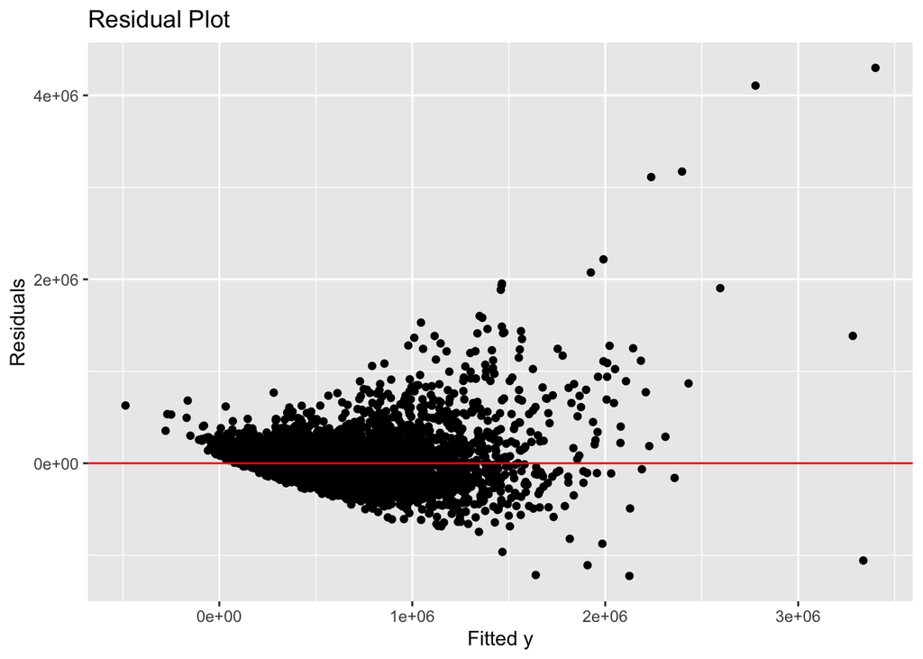

```r
res <- data.frame(fitted = regfull$fitted.values, residuals = regfull$residuals)
res %>%
  ggplot(aes(x = fitted, y = residuals)) +
  geom_point() +
  geom_hline(yintercept = 0, color = 'red') +
  labs(x = 'Fitted y', y = 'Residuals', title = 'Residual Plot')
```

Based on the residual plot, we can see signs of curvature and heteroskedasticity, which means assumptions 1 (linearity) and 2 (constant variance) are both not met yet. We will proceed with transforming the response variable (price) in order to meet assumption 2. If assumption 1 is still not met after transforming price, we will consider transforming a predictor variable.

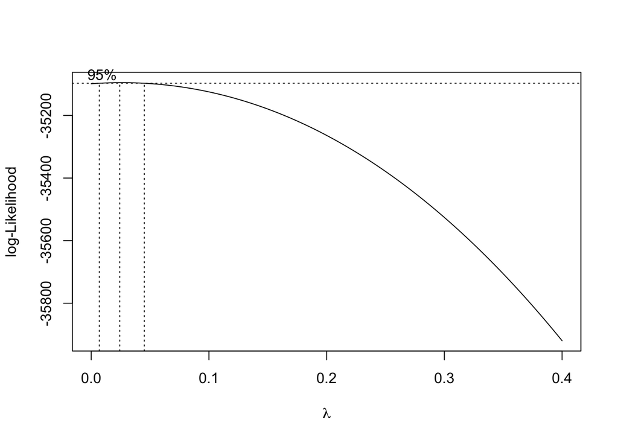

```r
boxcox(regfull, lambda = seq(0, 0.4, 0.01))
```

To determine what transformation to apply to the price, we generated a Box-Cox plot and found that the log-likelihood maximizing value of lambda seemed to lie between 0.01 and 0.05. To maintain interpretability of the model coefficients, we will select $\lambda = 0$, since it is close to the log-likelihood maximizing range. We will be applying a log transformation to price.

Transformation applied:

$y^* = log(y)$

```r
train <- train %>%
  mutate(log_price = log(price))

transformed <- lm(log_price ~ sqft_living + bedrooms + bathrooms + grade +
    good_area + waterfront + view + yr_built + renovated, data = train)
summary(transformed)
```

```
##
## Call:
## lm(formula = log_price ~ sqft_living + bedrooms + bathrooms +
##     grade + good_area + waterfront + view + yr_built + renovated,
##     data = train)
##
## Residuals:
##      Min       1Q   Median       3Q      Max
## -1.91524 -0.15052 -0.00607  0.14787  1.23829
##
## Coefficients:
##               Estimate Std. Error t value Pr(>|t|)
## (Intercept)  1.678e+01  2.052e-01  81.783  < 2e-16 ***
## sqft_living  1.928e-04  5.164e-06  37.335  < 2e-16 ***
## bedrooms    -9.105e-03  3.420e-03  -2.662  0.00777 **
## bathrooms    5.982e-02  5.401e-03  11.075  < 2e-16 ***
## grade        1.585e-01  3.495e-03  45.350  < 2e-16 ***
## good_area1   4.463e-01  5.315e-03  83.971  < 2e-16 ***
## waterfront1  4.573e-01  2.929e-02  15.610  < 2e-16 ***
## view         5.929e-02  3.605e-03  16.448  < 2e-16 ***
## yr_built    -2.918e-03  1.080e-04 -27.010  < 2e-16 ***
## renovated1   5.373e-02  1.233e-02   4.356 1.33e-05 ***
## ---
## Signif. codes:  0 '***' 0.001 '**' 0.01 '*' 0.05 '.' 0.1 ' ' 1
##
## Residual standard error: 0.2477 on 10796 degrees of freedom
## Multiple R-squared:  0.7791, Adjusted R-squared:  0.7789
## F-statistic:  4231 on 9 and 10796 DF,  p-value: < 2.2e-16
```

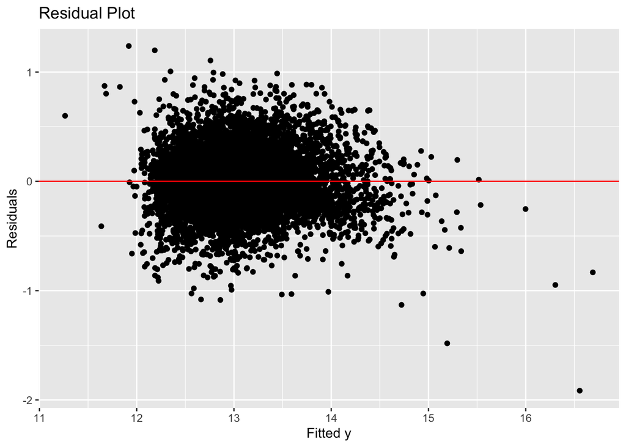

```r
res <- data.frame(fitted = transformed$fitted.values, residuals = transformed$residuals)
res %>%
  ggplot(aes(x = fitted, y = residuals)) +
  geom_point() +
  geom_hline(yintercept = 0, color = 'red') +
  labs(x = 'Fitted y', y = 'Residuals', title = 'Residual Plot')
```

Based on the residual plot of the model after transforming y, we can see that the variance is much better spread out now for assumption 2. There is still signs of curvature in the plot so we will consider transforming a predictor variable.

We will perform a log transformation on `sqft_living` since it is one of the predictors that is highly right skewed.

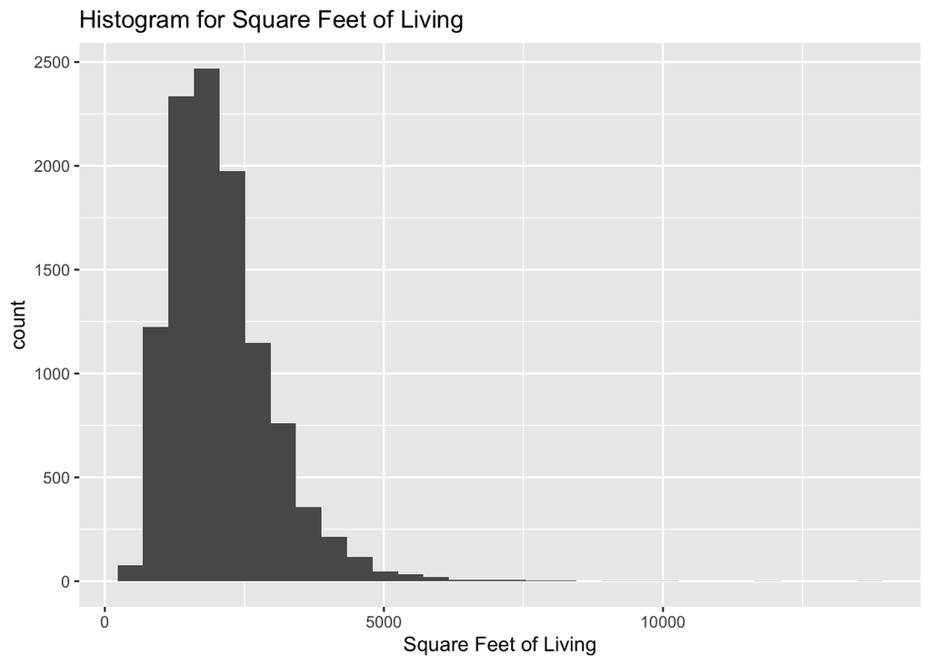

```r
train %>%
  ggplot(aes(x=sqft_living))+
  geom_histogram()+
  labs(x = 'Square Feet of Living', title="Histogram for Square Feet of Living")
```

```r
train <- train %>%
  mutate(log_sqft_living = log(sqft_living))

transformed_x_y <- lm(log_price ~ log_sqft_living + bedrooms + bathrooms + grade + view + yr_built +
    good_area + waterfront + renovated, data = train)
summary(transformed_x_y)
```

```
##
## Call:
## lm(formula = log_price ~ log_sqft_living + bedrooms + bathrooms +
##     grade + view + yr_built + good_area + waterfront + renovated,
##     data = train)
##
## Residuals:
##      Min       1Q   Median       3Q      Max
## -1.09716 -0.14834 -0.01014  0.14505  1.36224
##
## Coefficients:
##                   Estimate Std. Error t value Pr(>|t|)
## (Intercept)     14.4226479  0.2176996  66.250  < 2e-16 ***
## log_sqft_living  0.4549205  0.0111530  40.789  < 2e-16 ***
## bedrooms        -0.0280571  0.0035331  -7.941  2.2e-15 ***
## bathrooms        0.0606392  0.0052659  11.515  < 2e-16 ***
## grade            0.1591307  0.0033738  47.166  < 2e-16 ***
## view             0.0650174  0.0035459  18.336  < 2e-16 ***
## yr_built        -0.0032341  0.0001055 -30.660  < 2e-16 ***
## good_area1       0.4468567  0.0052553  85.029  < 2e-16 ***
## waterfront1      0.4633652  0.0289747  15.992  < 2e-16 ***
## renovated1       0.0416109  0.0121989   3.411  0.00065 ***
## ---
## Signif. codes:  0 '***' 0.001 '**' 0.01 '*' 0.05 '.' 0.1 ' ' 1
##
## Residual standard error: 0.245 on 10796 degrees of freedom
## Multiple R-squared:  0.7839, Adjusted R-squared:  0.7837
## F-statistic:  4352 on 9 and 10796 DF,  p-value: < 2.2e-16
```

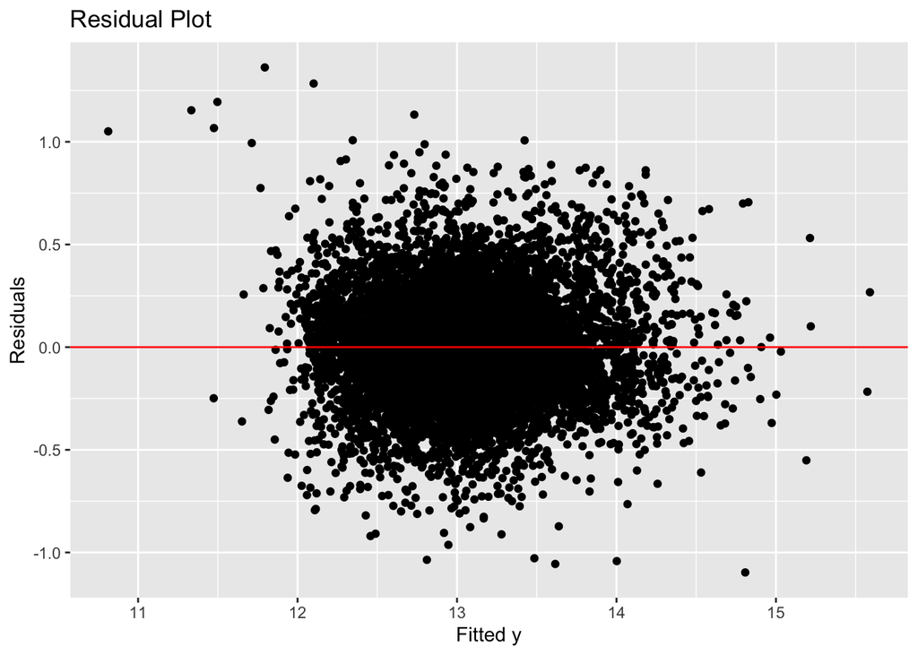

```r
res <- data.frame(fitted = transformed_x_y$fitted.values, residuals = transformed_x_y$residuals)
res %>%
  ggplot(aes(x = fitted, y = residuals)) +
  geom_point() +
  geom_hline(yintercept = 0, color = 'red') +
  labs(x = 'Fitted y', y = 'Residuals', title = 'Residual Plot')
```

Based on the residual plot, we can see that the curvature problem has been resolved. Both assumptions 1 and 2 are met.

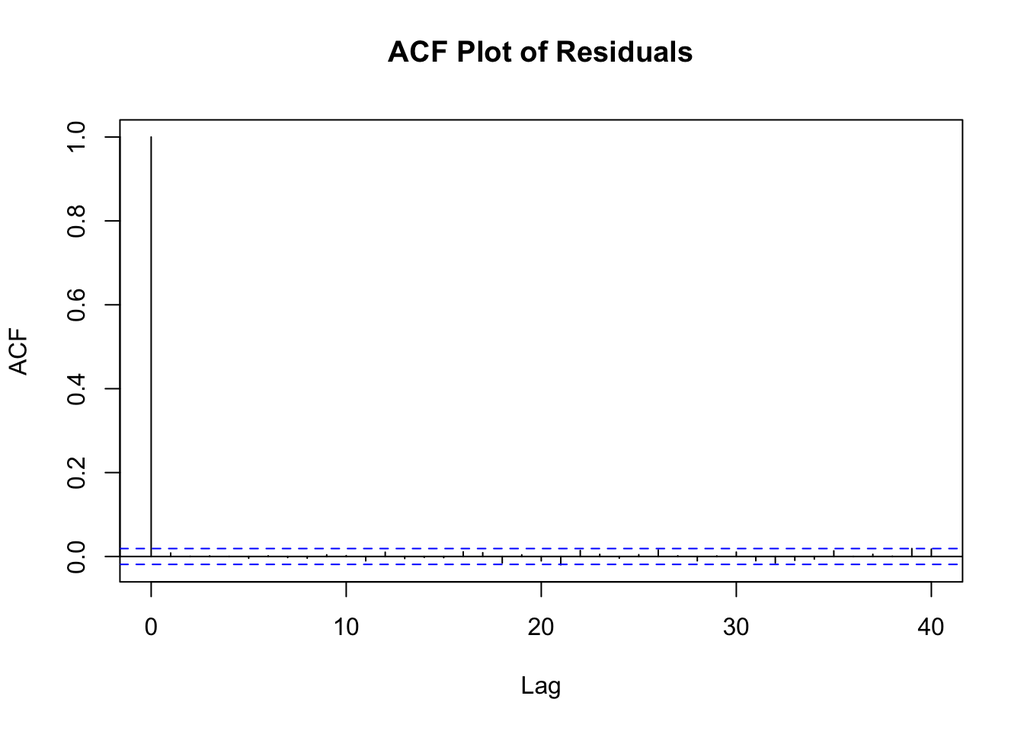

```r
acf(transformed_x_y$residuals, main = 'ACF Plot of Residuals')
```

Based on the ACF plot of the residuals, the error terms appear to be uncorrelated. Insignificant ACFs at lag 1 and greater indicate that the residuals are uncorrelated, so assumption 3, uncorrelated errors, is met.

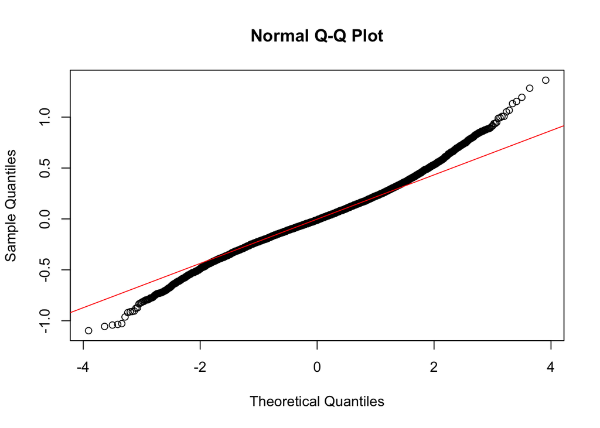

```r
qqnorm(transformed_x_y$residuals)
qqline(transformed_x_y$residuals, col = 'red')
```

The Normal Q-Q plot shows that, although our error terms do appear to be normally distributed for most of the theoretical quantiles, this relationship tends to break down at the extremes of the graph. Since this is the least necessary condition for linear regression to be valid, especially when the other assumptions are met, we decided to move forward with using the linear regression model.

### Levene’s test

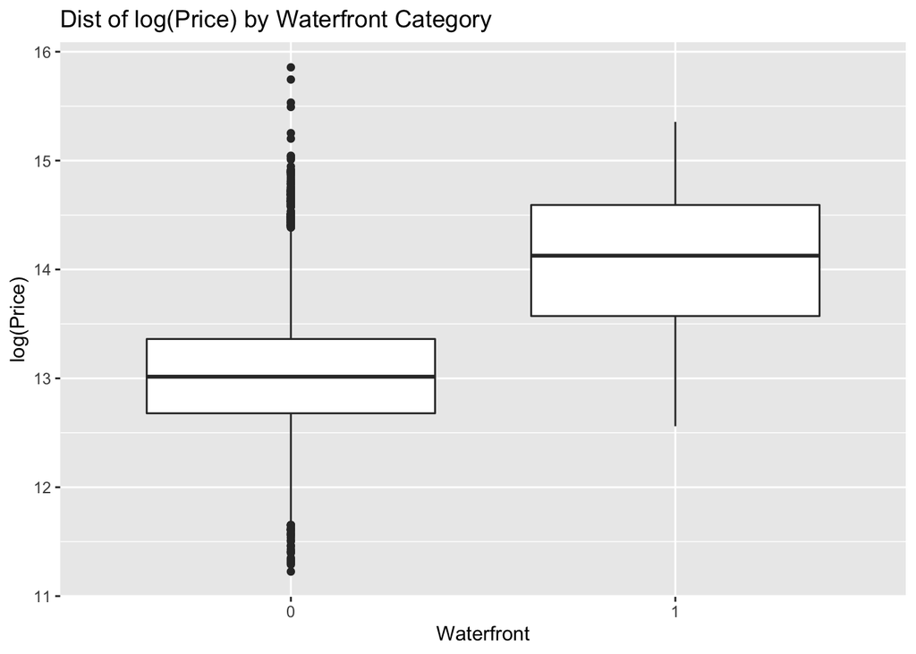

```r
ggplot(train, aes(x = waterfront, y = log_price))+
  geom_boxplot()+
  labs(x = 'Waterfront', y = 'log(Price)', title = 'Dist of log(Price) by Waterfront Category')
```

```r
levene.test(train$log_price, train$waterfront)
```

```
##
##  Modified robust Brown-Forsythe Levene-type test based on the absolute
##  deviations from the median
##
## data:  train$log_price
## Test Statistic = 14.667, p-value = 0.000129
```

```r
levene.test(train$log_price, train$renovated)
```

```
##
##  Modified robust Brown-Forsythe Levene-type test based on the absolute
##  deviations from the median
##
## data:  train$log_price
## Test Statistic = 39.512, p-value = 3.386e-10
```

```r
levene.test(train$log_price, train$good_area)
```

```
##
##  Modified robust Brown-Forsythe Levene-type test based on the absolute
##  deviations from the median
##
## data:  train$log_price
## Test Statistic = 93.746, p-value < 2.2e-16
```

For each categorical predictor used in this model, we conducted a Levene’s test. However, all of the results failed to support the assumption that variances are equal across all classes. Based on the nature of the data, we expect this to happen. In the dataset, houses that are ar the waterfront or have been renovated are in the minority.

```r
table(train$waterfront)
```

```
##
##     0     1
## 10719    87
```

```r
table(train$renovated)
```

```
##
##     0     1
## 10336   470
```

For `good_area`, the split used for this analysis is separating the really good areas from the rest. Because of that, the result of the Levene’s test is expected.

We will proceed with validating our regression model.

### Validation

```r
compute_press <- function(model) {
  residuals <- summary(model)$residuals
  hat_diagonals <- influence(model)$hat
  pr <- residuals/(1 - hat_diagonals)
  press <- sum(pr^2)
  return(press)
}

press <- compute_press(transformed_x_y)
press
```

```
## [1] 649.6636
```

```r
# use anova() to get the sum of squares for the linear model
lm_anova <- anova(transformed_x_y)
sst <- sum(lm_anova$'Sum Sq')

# calculate the predictive R^2
pred_r_squared <- 1 - press/(sst)
pred_r_squared
```

```
## [1] 0.7834337
```

$PRESS = 649.6636$

$R^2 = 0.7839$

$R^2_a = 0.7837$

$R^2_{pred} = 0.7834337$

Based on $R^2_{pred}, we can say that 78.34% of the variation in the response variable on new observations can be explained by our model.

Since all $R^2$ values are close to each other, we do not have a strong indication of overfitting.

### Residual Analysis

```r
ext.student.res <- rstudent(transformed_x_y)
student.res <- rstandard(transformed_x_y)
```

```r
res.frame <- data.frame(student.res, ext.student.res)
```

```r
n<-dim(train)[1]
p<-9
crit<-qt(1-0.05/(2*n), n-p-1)
```

```r
ext.student.res[abs(ext.student.res) > crit]
```

```
##     1022    10999    10998    19124    10903
## 4.627243 4.719159 5.255767 4.883469 5.570582
```

We have 5 outliers at observations 1022, 10903, 10998, 10999, and 19124

```r
##outlier observation
train[c('1022', '10903', '10998', '10999', '19124'),]
```

```
##         price sqft_living bedrooms bathrooms grade good_area waterfront view
## 1022  1050000        1330        4      1.00     6         1          0    0
## 10903  517534         833        2      1.00     5         0          0    0
## 10998  650000         920        1      1.00     6         0          0    0
## 10999  265000         384        0      0.75     4         0          0    0
## 19124  325000         410        1      0.75     4         0          0    0
##       yr_built renovated log_price log_sqft_living
## 1022      1952         0  13.86430        7.192934
## 10903     2006         0  13.15683        6.725034
## 10998     1996         1  13.38473        6.824374
## 10999     2003         0  12.48749        5.950643
## 19124     1953         0  12.69158        6.016157
```

### Leverage Points

```r
lev <- lm.influence(transformed_x_y)$hat ##identify high leverage points
length(lev[lev>2*p/n])
```

```
## [1] 1086
```

We have a lot of leverage points.

Influential points based on Cook’s distance

```r
##cooks distance
COOKS <- cooks.distance(transformed_x_y)
COOKS[COOKS>qf(0.5,p,n-p)]
```

```
## named numeric(0)
```

```r
##dffits
DFFITS <- dffits(transformed_x_y)
length(DFFITS[abs(DFFITS) > 2*sqrt(p/n)])
```

```
## [1] 758
```

We have no influential pointes based on Cook’s distance.

### Partial Regression Plots

```r
generate_partial_regression_plot <- function(response, predictor, predictors, lm_data) {
  filtered_predictors <- predictors[! predictors %in% c(predictor)]
  predictors_str <- paste(filtered_predictors, sep = ' + ')
  lm_no_x_str <- paste(response, predictors_str, sep = ' ~ ')
  x_lm_str <- paste(predictor, predictors_str, sep = ' ~ ')
  lm_no_x <- lm(lm_no_x_str, data = lm_data)
  x_lm <- lm(x_lm_str, data = lm_data)

  partial_data_x <- data.frame(x_res = summary(x_lm)$residuals, y_res = summary(lm_no_x)$residuals)

  x_label <- paste(predictor, 'Residuals', collapse = ' ')
  y_label <- paste('log(Price) Residuals excluding', predictor, collapse = ' ')
  title_str <- paste('Partial Regression Plot for', predictor, collapse = ' ')

  partial_data_x %>%
    ggplot(aes(x = x_res, y = y_res)) +
    geom_point() +
    geom_smooth(method = lm, se = FALSE) +
    labs(x = x_label, y = y_label, title = title_str)
}
```

```r
predictors = c('log_sqft_living', 'bedrooms', 'bathrooms', 'grade', 'view', 'yr_built', 'good_area', 'waterfront', 'renovated')
```

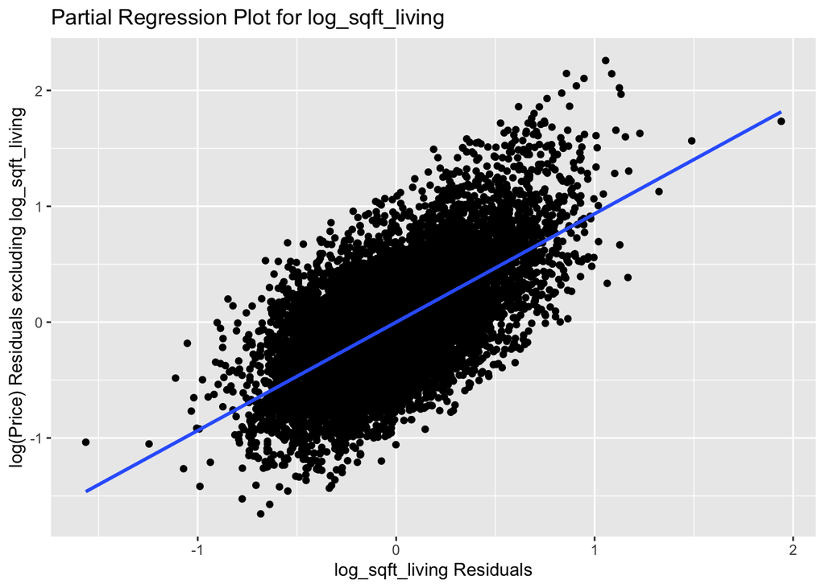

```r
generate_partial_regression_plot('log_price', 'log_sqft_living', predictors, train)
```

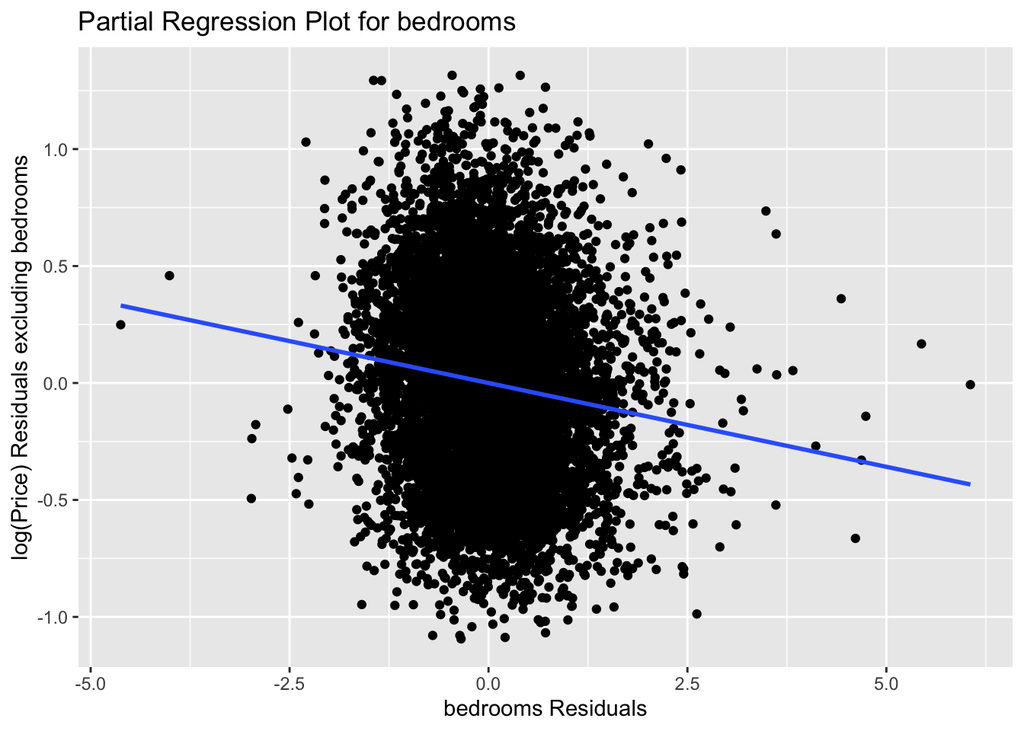

```r
generate_partial_regression_plot('log_price', 'bedrooms', predictors, train)
```

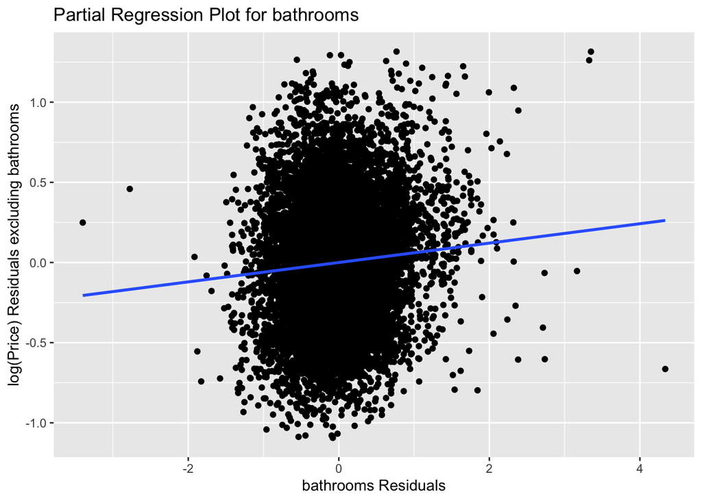

```r
generate_partial_regression_plot('log_price', 'bathrooms', predictors, train)
```

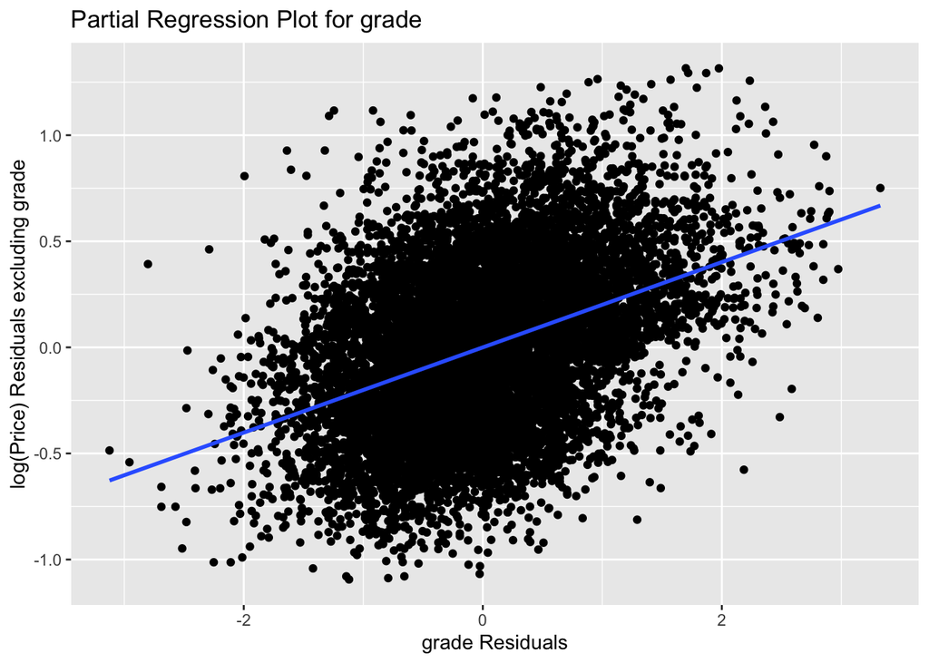

```r
generate_partial_regression_plot('log_price', 'grade', predictors, train)
```

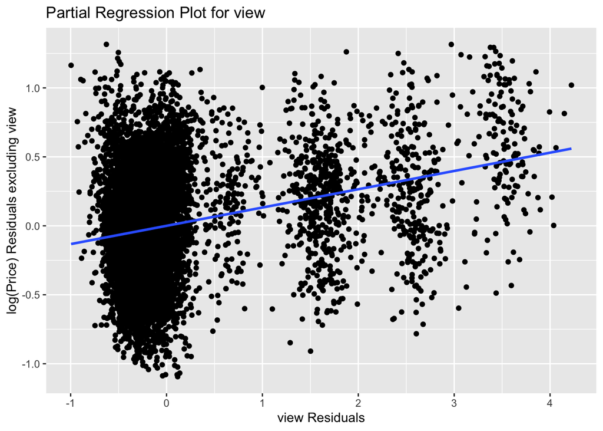

```r
generate_partial_regression_plot('log_price', 'view', predictors, train)
```

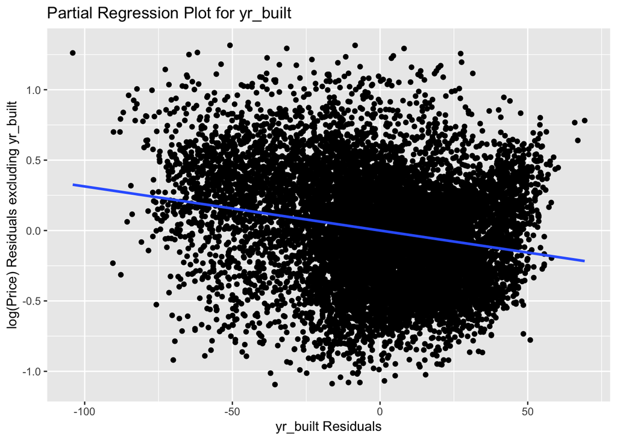

```r
generate_partial_regression_plot('log_price', 'yr_built', predictors, train)
```

Partial regression plots of the continuous predictors show linear patterns. This confirms that they can be added as linear predictors in the model.